# Bruce’s little playground

## Setup

```r
library(tidyverse)
library(tidymodels)
library(here)
library(pander)
```

```r
board_games <- read_csv(here("data/board_games.csv"))
```

## Year Published vs Rating

Here we see that average ratings have an overall upwards trend, with a brief plateau from 1980 to 2000 and then a sharp rise. This seems to suggest that the preference of the Board Game Geek community is more toward more recent games than older ones, and possibly that board games fall out of favour as they age, although as we have no past ratings data there is no way to verify this.

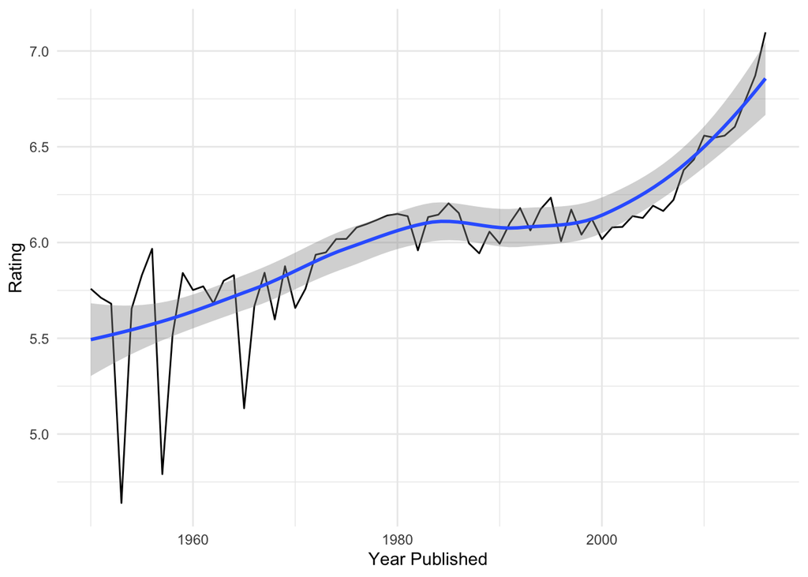

```r
board_games %>%
  group_by(year_published) %>%
  summarise(rating = mean(average_rating)) %>%
  ggplot(aes(
    x = year_published,
    y = rating
  )) +
  geom_line() +
  geom_smooth() +
  theme_minimal() +
  labs(
    x = "Year Published",
    y = "Rating"
  )
```

Fitting a linear regression we can see that the year a game was published does affect its ratings, but it is far from completely explaining it.

```r
year_published_rating_fit <- linear_reg() %>%
  set_engine("lm") %>%
  fit(average_rating ~ year_published, data = board_games)
```

$$R^2=0.095,R_{adj}^2=0.095.$$

## Year Published vs Number of Ratings

This graph shows us that the number of ratings a game has is fairly independent of the year that game was published, with the exception of a dip around 1980.

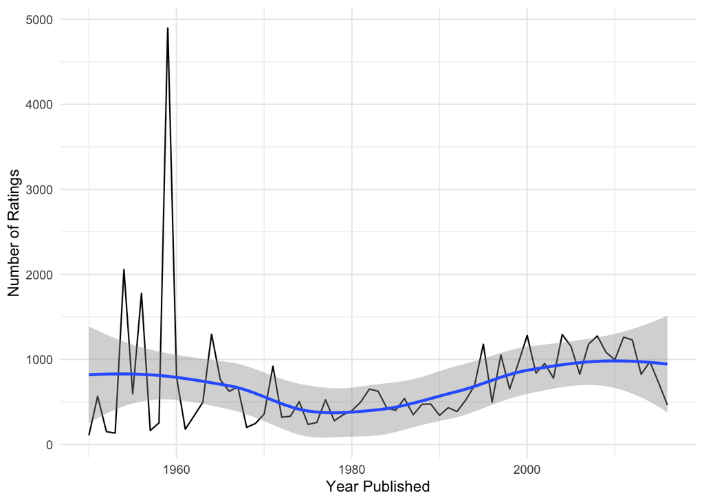

```r
board_games %>%
  group_by(year_published) %>%
  summarise(users = mean(users_rated)) %>%
  ggplot(aes(
    x = year_published,
    y = users
  )) +
  geom_line() +
  geom_smooth() +
  theme_minimal() +
  labs(
    x = "Year Published",
    y = "Number of Ratings"
  )
```

The spike at 1959 can be explained by a few games, namely *Risk* and *Diplomacy*, having very high numbers of ratings and there not being many other games realeased that year.

```r
board_games %>%
  filter(
    year_published == 1959
  ) %>%
  arrange(desc(users_rated)) %>%
  select(name, users_rated, year_published) %>%
  pander()
```

| name | users_rated | year_published |
| --- | --- | --- |
| Risk | 21836 | 1959 |
| Diplomacy | 9840 | 1959 |
| Memory | 1750 | 1959 |
| Football Strategy | 376 | 1959 |
| Piratenbillard | 336 | 1959 |
| Yum | 72 | 1959 |
| U-Boat | 62 | 1959 |

The coefficient of determination of our regression, as well as our graph, show us that year of publication is not a good predictor of number of ratings.

```r
year_published_users_rated_fit <- linear_reg() %>%
  set_engine("lm") %>%
  fit(users_rated ~ year_published, data = board_games)
```

$$R^2=0.002,R_{adj}^2=0.002.$$

## Most Popular Categories Over Time

First, we find the most popular categories overall.

```r
board_games_splitcats <- board_games %>%
  mutate(categories = str_split(category, ","))

popular_categories <- board_games_splitcats %>%
  pull(categories) %>%
  unlist %>%
  as_tibble %>%
  count(value) %>%
  arrange(desc(n)) %>%
  head(6) %>%
  pull(value)
```

Next, we find all of the games in each of these categories. We are okay with duplicate rows, as if a game is in two of the most popular categories we want it to be accounted for in both categories.

```r
board_games_empty <- board_games_splitcats %>%
  filter(FALSE)
board_games_popcats <- board_games_empty

for (c in popular_categories) {
  board_games_popcats <- full_join(
    board_games_popcats,
    board_games_splitcats %>%
      filter(map_lgl(categories, ~c %in% .x)) %>%
      mutate(category = c)
  )
}
```

Finally, we can plot the popularity of each category over time. Popularity, here, refers to the number of board games in each category as this is analogous to popularity among board game manufacturers.

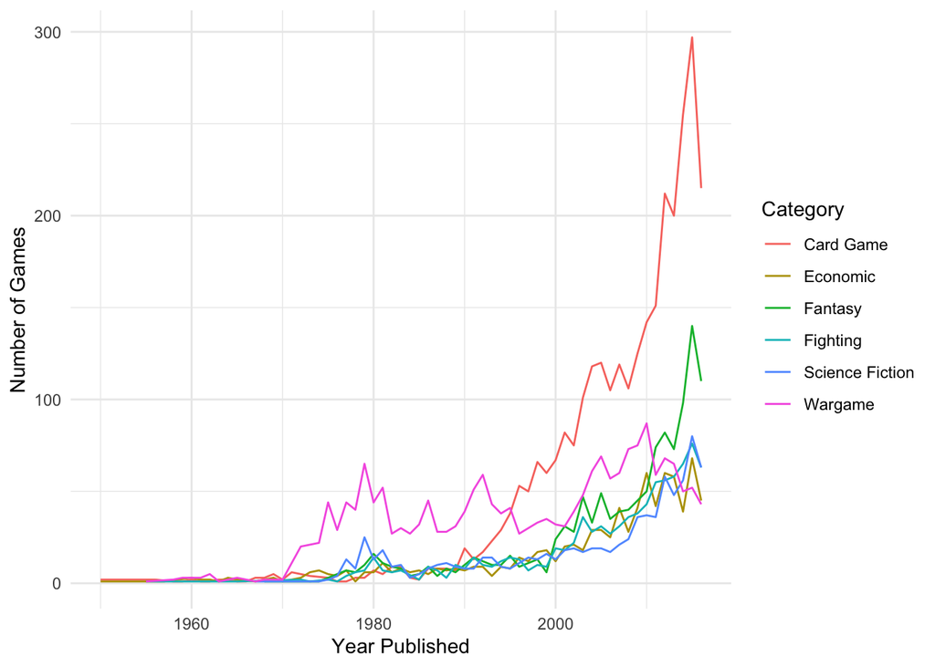

```r
board_games_popcats %>%
  group_by(category, year_published) %>%
  summarise(count = n()) %>%
  ggplot(aes(
    x = year_published,
    y = count,
    color = category
  )) +
  geom_line() +
  theme_minimal() +
  labs(
    x = "Year Published",
    y = "Number of Games",
    color = "Category"
  )
```